# 📊 Aula sobre Distribuições e Probabilidade

## 🧠 Introdução

As distribuições estatísticas estão profundamente conectadas ao conceito de **probabilidade** porque cada variável aleatória está associada a uma **distribuição de probabilidade**, que descreve como os valores possíveis da variável estão distribuídos e qual é a probabilidade associada a cada valor.

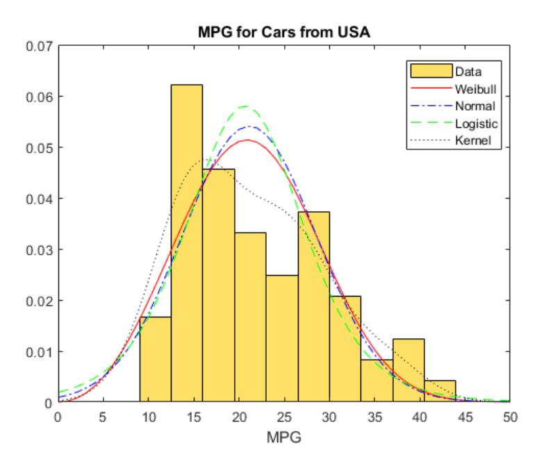

O conceito de variável aleatória é particularmente útil em situações nas quais se dispõe de um nível de conhecimento parcial ou incompleto do comportamento de uma grandeza que está sendo estudada. Essa incerteza pode ser então introduzida sob a forma de um modelo probabilístico.

Por exemplo, um gestor hospitalar encarregado de realizar estudos em uma unidade de emergência mede o tempo que os pacientes gastam para serem atendidos após chegarem ao hospital. Naturalmente, para cada paciente o tempo de espera depende da gravidade do caso e da disponibilidade de profissionais. Suponha que, para uma determinada unidade de emergência, o tempo médio de espera seja de 60 minutos. Aqui, a variável aleatória é X = “tempo em minutos gasto na espera pelo atendimento”, e tudo indica que, para pacientes com menor gravidade, é alta a probabilidade 𝑃(𝑋>60).

🔗 Conectando Distribuições e Probabilidade

Distribuições são, essencialmente, representações gráficas da **probabilidade**. Dependendo do tipo de variável (discreta ou contínua), a forma de calcular e interpretar a probabilidade varia.

## 🎲 Distribuições Discretas: Função de Massa de Probabilidade (FMP)

Dizemos que X é uma variável aleatória discreta se o número de valores que ela pode admitir é finito. Por exemplo, em uma clínica médica, o número de pacientes atendidos por dia é anotado para fins de monitoramento da demanda. Suponha que, em determinado período, o número de pacientes atendidos diariamente varia entre 0 e 20. Nesse caso, a v.a. X é o número de pacientes atendidos por dia. Assim, X pode admitir os valores 0, 2, 3, 4, ..., 10, 11, 12, 13, 14, ..., 20. Portanto, claramente X é uma v.a. aleatória discreta.

Uma distribuição discreta descreve a probabilidade de ocorrência de cada valor de uma variável aleatória discreta. Com uma distribuição de probabilidade discreta, cada valor possível da variável aleatória discreta pode ser associado a uma probabilidade diferente de zero. Deste modo, uma distribuição de probabilidade discreta é, por vezes, apresentada em forma de tabela. Com uma distribuição discreta é possível calcular a probabilidade de que X seja exatamente igual ou maior ou menor que algum valor.

A **Função de Massa de Probabilidade (FMP)** atribui probabilidades a valores específicos de uma variável aleatória discreta.

P(X = x) = f(x)

Essa fórmula indica que a probabilidade da variável (X) assumir um valor específico (x) é dada pela função de massa de probabilidade (f(x)).

Para esse caso, a distribuição que melhor se aplica é a Distribuição de Poisson, pois estamos lidando com a contagem de eventos (número de pacientes atendidos por dia) em um intervalo de tempo fixo (um dia).

A Distribuição de Poisson é usada para modelar a probabilidade de um número específico de eventos ocorrer em um intervalo de tempo ou espaço, quando os eventos ocorrem de forma independente e com uma taxa média conhecida.

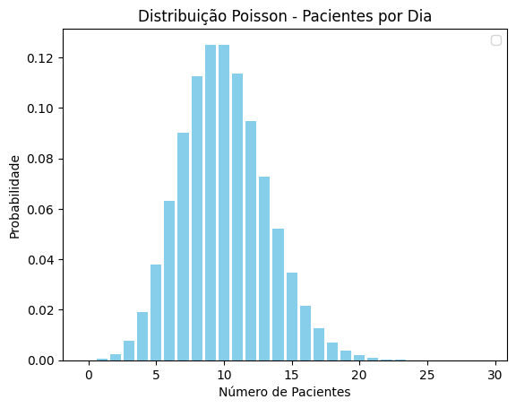

```python
import scipy.stats as stats
import matplotlib.pyplot as plt
import numpy as np

media = 10  # Média de pacientes por hora
x = np.arange(0, 30)
y = stats.poisson.pmf(x, media)

plt.bar(x, y, color='skyblue')
plt.title('Distribuição Poisson - Pacientes por Dia')
plt.xlabel('Número de Pacientes')
plt.ylabel('Probabilidade')
plt.legend()
plt.show()
```

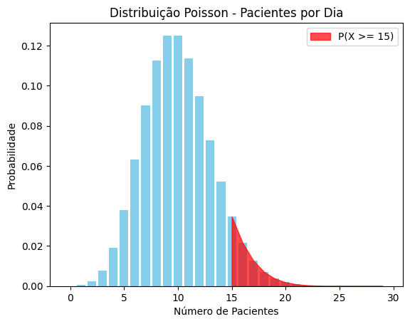

```python
import scipy.stats as stats

media = 10  # Média de pacientes por hora
x = np.arange(0, 30)
y = stats.poisson.pmf(x, media)

plt.bar(x, y, color='skyblue')
plt.title('Distribuição Poisson - Pacientes por Dia')
plt.xlabel('Número de Pacientes')
plt.ylabel('Probabilidade')
plt.fill_between(x, y, where=(x >= 15), color='red', alpha=0.7, label='P(X >= 15)')
plt.legend()
plt.show()
```

stats.poisson.sf(k, mu)

Onde:

- k é o valor a partir do qual queremos calcular a probabilidade (no nosso caso, 14).
- mu é a média da distribuição de Poisson (no nosso caso, variável media).

```python
probabilidade_x_maior_igual_15 = stats.poisson.sf(14, media)

print(f"A probabilidade de X >= 15 é: {probabilidade_x_maior_igual_15:.4f}")
```

```
A probabilidade de X >= 15 é: 0.0835
```

A altura das barras somam 0,0835; por conseguinte, a probabilidade de que o número de pacientes atendidos por dia seja de 15 ou mais é 8,35%.

Ao longo desse módulo, apresentaremos a alguns dos modelos probabilísticos discretos que costumam ser mais utilizados nas aplicações práticas da Estatística em saúde. Existem diversas modelagens para prever a probabilidade de variáveis discretas, como os modelos que envolvem ensaios de Bernoulli (Bernoulli, Binomial, Geométrico) e o modelo de Poisson.

## 🌊 Distribuições Contínuas: Função Densidade de Probabilidade (FDP)

A distribuição contínua descreve as probabilidades dos possíveis valores de uma variável aleatória contínua. Uma variável aleatória contínua é uma variável aleatória com um conjunto de valores possíveis (conhecidos como intervalos) que é infinito e incontável.

As probabilidades de variáveis aleatórias contínuas ( 𝑋) são definidas como a área sob a curva da sua distribuição. Assim, apenas as faixas de valores podem ter uma probabilidade diferente de zero. A probabilidade de que uma variável aleatória contínua seja igual a algum valor é sempre zero. Isso acontece porque a probabilidade de uma variável contínua assumir exatamente um valor específico é sempre zero.

Normal (Contínua): "Qual é a probabilidade de um paciente pesar 70 kg?" → Sempre zero.

A **Função Densidade de Probabilidade (FDP)** não atribui a probabilidade a um único valor, mas sim à área sob a curva em um intervalo.

Exemplo de Distribuição Normal: A distribuição normal é uma das mais comuns e segue a famosa curva em sino.

O peso de pacientes em um hospital pode ser modelado como uma distribuição normal.

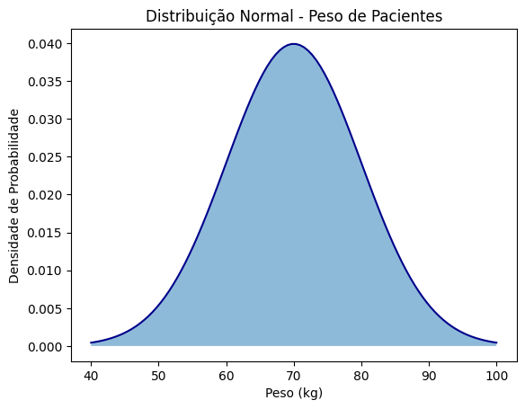

```python
media = 70  # Média de peso em kg
desvio = 10  # Desvio padrão
x = np.linspace(40, 100, 100) #A função np.linspace(40, 100, 100) cria uma série de 100 valores igualmente espaçados entre 40 e 100.
y = stats.norm.pdf(x, media, desvio) #A função stats.norm.pdf(x, media, desvio) calcula a função densidade de probabilidade (FDP) da Distribuição Normal para cada valor em x
#Isso retorna uma lista de valores de densidade para cada peso no intervalo.

plt.plot(x, y, color='darkblue')
plt.title('Distribuição Normal - Peso de Pacientes')
plt.xlabel('Peso (kg)')
plt.ylabel('Densidade de Probabilidade')
plt.fill_between(x, y, alpha=0.5)
plt.show()
```

## 📊 Função de distribuição cumulativa (CFD)

A Função de Distribuição Acumulada (CDF) pode ser calculada tanto para variáveis discretas quanto para variáveis contínuas. No entanto, a forma de interpretação e o cálculo específico variam conforme o tipo de variável.

Em todo caso, a interpretação final é a mesma: probabilidade acumulada até o ponto x.

### 📊 CDF para Variáveis Discretas

A CDF para variáveis discretas é a soma acumulada das probabilidades de todos os valores menores ou iguais a um valor específico.

🚀 Exemplo: Distribuição Binomial Vamos calcular a probabilidade acumulada de obter até 3 sucessos em 10 tentativas com uma probabilidade de sucesso de 20%.

```python
from scipy.stats import binom

# Parâmetros
n = 10  # Número de tentativas
p = 0.20  # Probabilidade de sucesso
x = 3  # Número máximo de sucessos

# Cálculo da CDF
prob_acumulada = binom.cdf(x, n, p)
print(f"🔢 A probabilidade acumulada de obter até 3 sucessos é: {prob_acumulada:.4%}")
```

```
🔢 A probabilidade acumulada de obter até 3 sucessos é: 87.9126%
```

### 🌊 CDF para Variáveis Contínuas

A CDF para variáveis contínuas é a integração da função densidade de probabilidade (FDP) da esquerda até o valor desejado.

🚀 Exemplo: Distribuição Normal Calcular a probabilidade acumulada de um paciente ter peso até 80 kg, sabendo que a média é 70 kg e o desvio padrão é 10 kg.

```python
from scipy.stats import norm

# Parâmetros
media = 70  # Média de peso
desvio = 10  # Desvio padrão
x = 80  # Peso máximo

# Cálculo da CDF
prob_acumulada = norm.cdf(x, media, desvio)
print(f"📏 A probabilidade acumulada de pesar até 80 kg é: {prob_acumulada:.4%}")
```

```
📏 A probabilidade acumulada de pesar até 80 kg é: 84.1345%
```

```python
probabilidade = stats.norm.cdf(80, media, desvio) - stats.norm.cdf(60, media, desvio)
print(f'A probabilidade de um paciente ter peso entre 60 e 80 kg é: {probabilidade:.4f}')
```

```
A probabilidade de um paciente ter peso entre 60 e 80 kg é: 0.6827
```

- Esta expressão calcula a probabilidade acumulada de que o peso de um paciente seja menor ou igual a 80 kg.
- Também culcula a probabilidade acumulada de que o peso de um paciente seja menor ou igual a 60 kg.
- A subtração das duas probabilidades acumuladas calcula a probabilidade de um paciente ter peso entre 60 e 80 kg.

A função de distribuição acumulada (CDF) nos dá a área sob a curva até um determinado ponto. Para calcular a probabilidade em um intervalo (60≤X≤80), fazemos: P(60≤X≤80)=P(X≤80)−P(X≤60) Essa subtração remove a parte da probabilidade acumulada que está antes dos 60 kg, deixando apenas a probabilidade dentro do intervalo desejado.

### 🌟 SF: A Função de Sobrevivência (Survival Function) - O Complemento da CDF

A Função de Sobrevivência (SF) é simplesmente o complemento da CDF (Função de Distribuição Acumulada). Enquanto a CDF calcula a probabilidade acumulada até um determinado valor, a SF calcula a probabilidade acumulada a partir desse valor.

🏥 Exemplo na Saúde: Número de Internações Vamos considerar um exemplo:

Um hospital tem uma média de 5 internações por dia. Queremos saber a probabilidade de ter mais de 7 internações em um dia

```python
from scipy.stats import poisson

# Parâmetros
media = 5  # Média de internações por dia
x = 7  # Número de internações desejado

# Cálculo da SF (Survival Function)
prob_mais_que_7 = poisson.sf(x, media)

print(f"🚑 A probabilidade de ter mais de 7 internações em um dia é: {prob_mais_que_7:.4%}")
```

```
🚑 A probabilidade de ter mais de 7 internações em um dia é: 13.3372%
```

Por Que Usar a SF ao Invés da CDF?

- Quando queremos a probabilidade de ultrapassar um valor específico.
- Para facilitar o cálculo de valores extremos sem ter que somar manualmente todas as probabilidades superiores.
- Para variáveis contínuas ou discretas, funciona da mesma forma, pois sempre calcula o complemento da CDF.

Quando Usar Cada Uma:

- CDF: Quando queremos a probabilidade menor ou igual a um valor específico.
- SF: Quando queremos a probabilidade maior que um valor específico.

## 💡 Modelar é primeiro saber qual distribuição se acomoda os dados

"A essência da análise estatística é confrontar as hipóteses de uma distribuição de probabilidades com as especificações de determinado problema."

Isso significa que o primeiro passo da análise estatística é formular uma hipótese sobre qual distribuição de probabilidade melhor representa o fenômeno que estamos analisando.

Por exemplo:

- No estudo do peso corporal de pacientes, podemos usar uma distribuição Normal.
- Para modelar o tempo de espera em uma fila, podemos usar uma distribuição Exponencial.

A hipótese sobre a distribuição define os métodos estatísticos que podemos utilizar, como testes de hipóteses, intervalos de confiança e modelos preditivos.

Se escolhermos a distribuição errada, nossas inferências e conclusões podem ser inadequadas ou errôneas.

"Se a situação real que você analisa se aproxima fortemente de uma distribuição de probabilidades já conhecida, sua análise fica muito mais simples, como veremos adiante."

A escolha de uma distribuição bem ajustada aos dados simplifica a análise estatística, pois permite o uso de fórmulas analíticas prontas e bem estabelecidas.

Se os dados seguem uma distribuição normal, por exemplo, podemos aplicar diretamente:

- Testes Z e T
- Intervalos de confiança
- Testes de hipóteses paramétricos

As distribuições já conhecidas têm teorias robustas e ferramentas analíticas consolidadas, como testes e intervalos específicos.

A partir de uma boa escolha de distribuição, podemos utilizar métodos prontos e bem fundamentados para analisar os dados, economizando tempo e esforço.

Portanto, reconhecer padrões nos dados e associá-los a uma distribuição conhecida permite modelar e prever eventos de maneira eficiente e confiável. Isso está na essência da estatística aplicada e é a base de praticamente todas as análises estatísticas inferenciais.

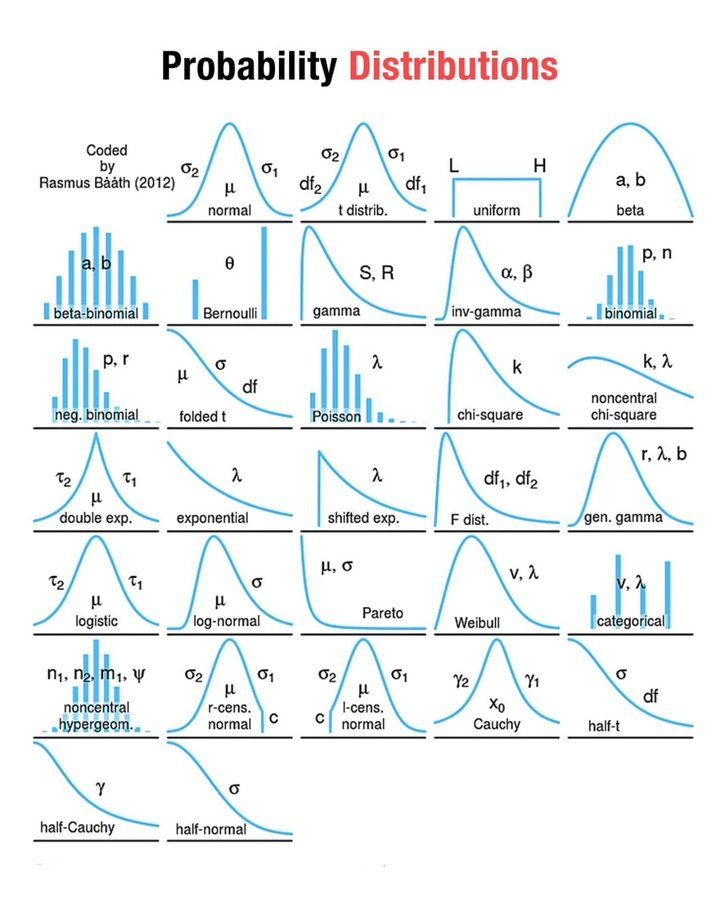

```python
# Ver versões atuais (só p/ conferir)
import sys, numpy, scipy
print(sys.version)
print("numpy:", numpy.__version__)
print("scipy:", scipy.__version__)
```

```
3.12.11 (main, Jun  4 2025, 08:56:18) [GCC 11.4.0]
numpy: 1.26.4
scipy: 1.12.0
```

```python
%pip install -q --upgrade --force-reinstall \
  "numpy==2.0.2" "scipy==1.14.1" "matplotlib>=3.8" "pandas>=2.1" "fitter==1.7.0"
```

[output not shown]

```python
import numpy as np, scipy, matplotlib, pandas
from fitter import Fitter
print("numpy", np.__version__, "| scipy", scipy.__version__)
```

```
numpy 1.26.4 | scipy 1.12.0
```

[output not shown]

```
Melhor (SSR): {'lognorm': {'s': 0.022338977389845097, 'loc': -139.80594679114103, 'scale': 310.07191652972034}}
```

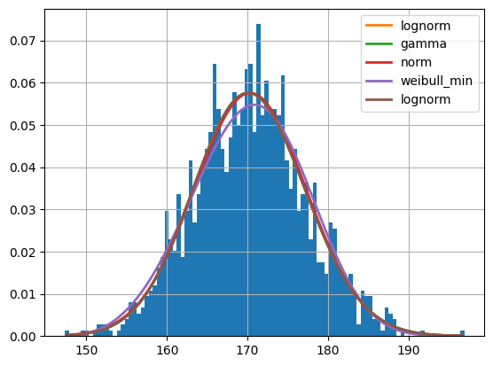

```python
import numpy as np
from fitter import Fitter
import matplotlib.pyplot as plt

np.random.seed(42)
dados = np.random.normal(loc=170, scale=7, size=1500)

f = Fitter(dados, distributions=['norm','lognorm','gamma','weibull_min'])
f.fit()
f.summary(Nbest=5)
print("Melhor (SSR):", f.get_best(method='sumsquare_error'))

ax = f.plot_pdf(Nbest=1)
plt.show()
```